# Let's Talk about Python

### Derik Pack

### November 29, 2022

## BLUF

**We are talking about Python 3 here, people!**

- https://www.python.org/
- https://education.python.org/
- https://software-carpentry.org/
- https://circuitpython.org/
- https://micropython.org/
- https://www.raspberrypi.com/products/raspberry-pi-pico/
- **https://www.w3schools.com/python/** - An intro to Python syntax
- **https://exercism.org/** - A free code challenge website
- **https://pybit.es/** - The first coding platform I ever used (Free & premium content)

## Hello World!

```python
print("Hello World!")
```

```
Hello World!
```

```python
print("Hello World from 🐍!")
```

```
Hello World from 🐍!
```

## 10 Facts about Python

1. Initially released on 20 Feb 1991
2. Creator has the coolest name and title, Guido van Rossum, Benevolent Dictator for Life (retired)
3. Currently on a yearly release cadence.
4. Curly braces not required - whitespace identation (No flame wars on spaces vs tabs, please)
5. Supports object oriented, procedural and functional programming paradigms
6. It has its own Zen. Type 'import this' at a REPL.

The Zen of Python, by Tim Peters

Beautiful is better than ugly.  
Explicit is better than implicit.  
Simple is better than complex.  
Complex is better than complicated.  
Flat is better than nested.  
Sparse is better than dense.  
Readability counts.  
Special cases aren't special enough to break the rules.  
Although practicality beats purity.  
Errors should never pass silently.  
Unless explicitly silenced.  
In the face of ambiguity, refuse the temptation to guess.  
There should be one-- and preferably only one --obvious way to do it.  
Although that way may not be obvious at first unless you're Dutch.  
Now is better than never.  
Although never is often better than *right* now.  
If the implementation is hard to explain, it's a bad idea.  
If the implementation is easy to explain, it may be a good idea.  
Namespaces are one honking great idea -- let's do more of those!

7. Batteries included.

```python
"""
    Let's see how many members are in our CSV file
    and the most used email domain and least used domain.
"""
import csv
from collections import Counter

c = Counter()
with open('members.csv','r') as FILE:
    reader = csv.DictReader(FILE)
    members = list(reader)
    print(f"There are {len(members)} total members.")
    for member in members:
        domain = member["Email Address"].split("@")[-1]
        c[domain]+=1
m_c_domains = c.most_common()
mcd, lcd = m_c_domains[0], m_c_domains[-1]
print(f"The most common domain is {mcd[0]} with {mcd[1]} member")
print(f"The least common domain is {lcd[0]} with {lcd[1]} member")
```

```
There are 4 total members.
The most common domain is example.com with 3 member
The least common domain is gmail.com with 1 member
```

8. It's dynamically typed and garbage collected

```python
changing_var = 8
print(changing_var)
changing_var = "hello"
print(changing_var)
```

```
8
hello
```

9. The current version (Nov 2022) is 3.11. A version 4.0 is highly unlikely

10.There are 2 variants of Python focused on microcontrollers: Micropython and CircuitPython

## Who is using Python?

[figure not shown]

...and many many more!

# How are people using it?

```python
from wordcloud import WordCloud
import matplotlib.pyplot as plt
import csv
with open('wordcloud.csv','r') as WCFILE:
    word_freq = list(csv.reader(WCFILE))
    word_freq_dict = {row[0]:int(row[1]) for row in word_freq[1:]}
wc = WordCloud(max_font_size=40, height=150,width=300,
                  background_color='white')
cloud = wc.generate_from_frequencies(word_freq_dict)
```

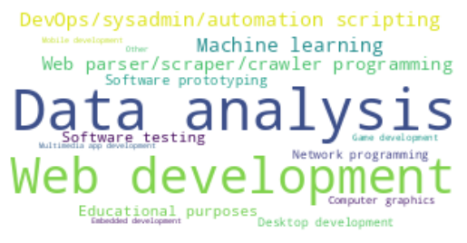

```python
plt.imshow(cloud, interpolation='bilinear');plt.axis("off");plt.show()
```

Created from Jetbrains Python Developer survey data at https://lp.jetbrains.com/python-developers-survey-2021/

## How am I using Python?

- https://github.com/packdl/circuit-python-projects
- https://github.com/packdl/letter-boxed-solver
- https://github.com/packdl/bcsd-covid-dashboard

## Installing Python

***Really CPython***

You always can go to https://www.python.org/downloads/ to download a particular release of Python

- Windows: Install from the Windows Store
- Linux: Don't update the system Python
- Mac: Don't update the system Python
- Others: There are still people installing Python on their HP-UX mainframe

And learn about [virtual environments](https://docs.python.org/3/library/venv.html)

## Python for Microcontrollers

1. https://micropython.org/
2. https://circuitpython.org/

Thank Microsoft for [UF2](https://github.com/microsoft/uf2). Flashing your microcontrollers is now pretty easy to do.

Both MicroPython and CircuitPython are Python 3 variants.  
Common Traits

- Fewer batteries included
- Both are closer to Python 3.4 than Python 3.11

Differences

- MicroPython has some more adanced features like threading
- CircuitPython is focused on ease of learning

## Integrated Development Environments

1. [Thonny](https://thonny.org/)
   - Installed on Raspberry Pi SBCs
   - Great support for MicroPython!
2. [Mu](https://codewith.mu/)
   - Recommended by Adafruit for CircuitPython development
   - Simple UI
3. [Visual Studio Code](https://code.visualstudio.com/)
   - Highest learning curve
   - A significant plugin marketplace
   - Can support multiple languages

## Python & Raspberry Pi

The Raspberry Pi Foundation has both Single Board Computers (SBC) and microcontrollers

SBCs

- Raspberry Pi 1, 3, 4
- Raspberry Pi 400
- Raspberry Pi Zero, Zero W, Zero 2 W

Microcontrollers

- RP2040
- Raspberry Pi Pico, Pico W

## Programming your device

- [Raspberry Pi 4 Model B](https://www.raspberrypi.com/products/raspberry-pi-4-model-b/)
- [Raspberry Pi Pico](https://www.raspberrypi.com/products/raspberry-pi-pico/)
- [Adafruit Macropad](https://learn.adafruit.com/adafruit-macropad-rp2040)

## Programming your Raspberry PI 4 Model B

- Supported IDEs: Thonny, Mu, VsCode
- Python: CPython
- Libraries: gpiozero, SMBus, **[Adafruit_Blinka](https://learn.adafruit.com/circuitpython-on-raspberrypi-linux/installing-circuitpython-on-raspberry-pi)**-CircuitPython APIs

## Programming your Raspberry PI Pico

- Supported IDEs: Thonny, Mu, VSCode
- Python: MicroPython or [CircuitPython](https://learn.adafruit.com/getting-started-with-raspberry-pi-pico-circuitpython/circuitpython?gclid=Cj0KCQiAsoycBhC6ARIsAPPbeLusDYEGMgJFvMF69RcehBOWyOIXKEGIS8TWBeDE32qsP1gw8mY8Co4aAncrEALw_wcB)
- Libraries: Various CircuitPython or Micropython libraries

## Programming your Adafruit Macropad

- Supported IDEs: Thonny, Mu, VSCode
- Python: [CircuitPython](https://learn.adafruit.com/getting-started-with-raspberry-pi-pico-circuitpython/circuitpython?gclid=Cj0KCQiAsoycBhC6ARIsAPPbeLusDYEGMgJFvMF69RcehBOWyOIXKEGIS8TWBeDE32qsP1gw8mY8Co4aAncrEALw_wcB)
- Libraries: [CircuitPython official and community bundle](https://circuitpython.org/libraries)

## Morse Code Macropad

Let's look at our [Macropad project](https://github.com/packdl/circuit-python-projects/tree/main/MorseCodeMacropad) to create a keyboard to type in Morse code and play the Morse code on a speaker.

[figure not shown]

## The community is amazing!

- https://www.youtube.com/c/pyconus/videos
- https://pyvideo.org
- https://pyvideo.org/pyohio-2013/python-101.html
- https://learn.adafruit.com
- https://docs.micropython.org/en/latest/index.html
- https://talkpython.fm/episodes/all
- https://wiki.python.org/moin/IntroductoryBooks